# Red Wine Analysis with R By Christopher Boone

The wineQualityReds data set contains 12 variables that describe different aspects of 1599 different red wines. The variables consist of: fixed acidity, volatile acidity, citric acid, residual sugar, chlorides, free sulfur dioxide, total sulfur dioxide, density, pH, sulphates, alcohol, and quality.

# Univariate Plots Section

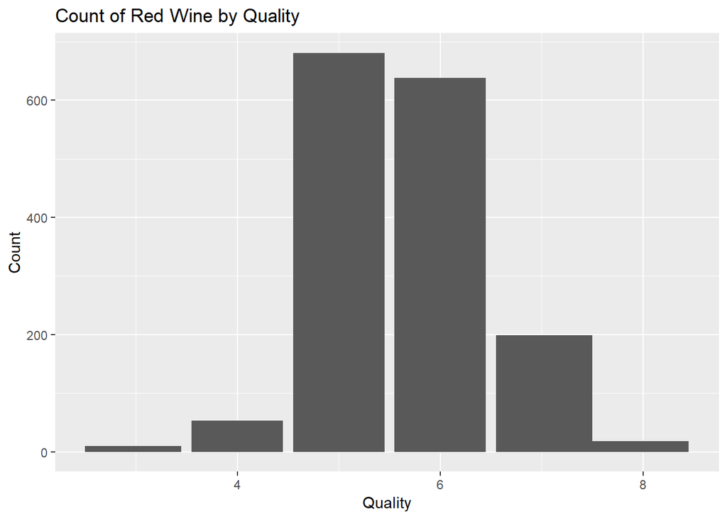

We can see by this graph that the wine quality has an even distribution and is centralized on 5 and 6 which gives us an approx median of 6.

```
## 'data.frame':    1599 obs. of  13 variables:
##  $ X                   : int  1 2 3 4 5 6 7 8 9 10 ...
##  $ fixed.acidity       : num  7.4 7.8 7.8 11.2 7.4 7.4 7.9 7.3 7.8 7.5 ...
##  $ volatile.acidity    : num  0.7 0.88 0.76 0.28 0.7 0.66 0.6 0.65 0.58 0.5 ...
##  $ citric.acid         : num  0 0 0.04 0.56 0 0 0.06 0 0.02 0.36 ...
##  $ residual.sugar      : num  1.9 2.6 2.3 1.9 1.9 1.8 1.6 1.2 2 6.1 ...
##  $ chlorides           : num  0.076 0.098 0.092 0.075 0.076 0.075 0.069 0.065 0.073 0.071 ...
##  $ free.sulfur.dioxide : num  11 25 15 17 11 13 15 15 9 17 ...
##  $ total.sulfur.dioxide: num  34 67 54 60 34 40 59 21 18 102 ...
##  $ density             : num  0.998 0.997 0.997 0.998 0.998 ...
##  $ pH                  : num  3.51 3.2 3.26 3.16 3.51 3.51 3.3 3.39 3.36 3.35 ...
##  $ sulphates           : num  0.56 0.68 0.65 0.58 0.56 0.56 0.46 0.47 0.57 0.8 ...
##  $ alcohol             : num  9.4 9.8 9.8 9.8 9.4 9.4 9.4 10 9.5 10.5 ...
##  $ quality             : int  5 5 5 6 5 5 5 7 7 5 ...
```

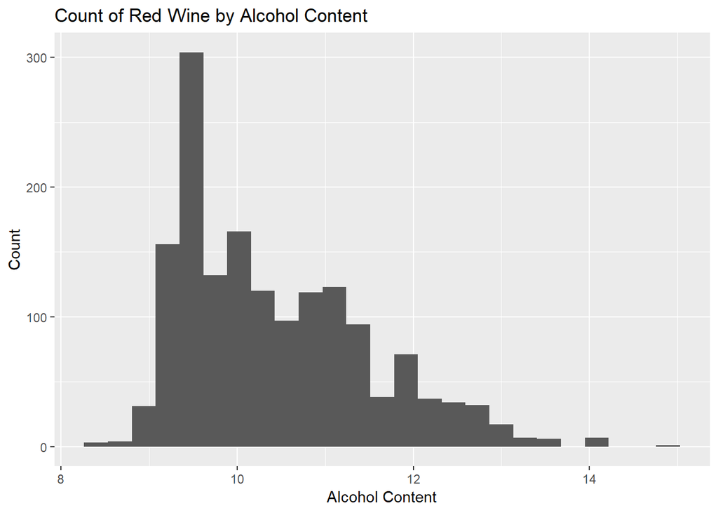

When we tak a count of wines by alcohol content we can see that the count is right skewed. We can also see that we have some outliers in the data set.

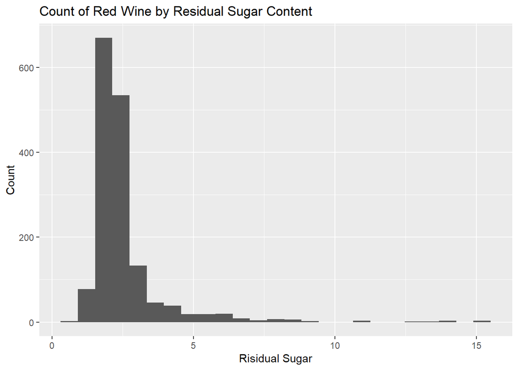

```
## [1] 2.2
```

```
## [1] 2.538806
```

We can see that residual sugar is right skewed and have a few groups of outliers. The median sits at 2.2 and a mean of 2.54.

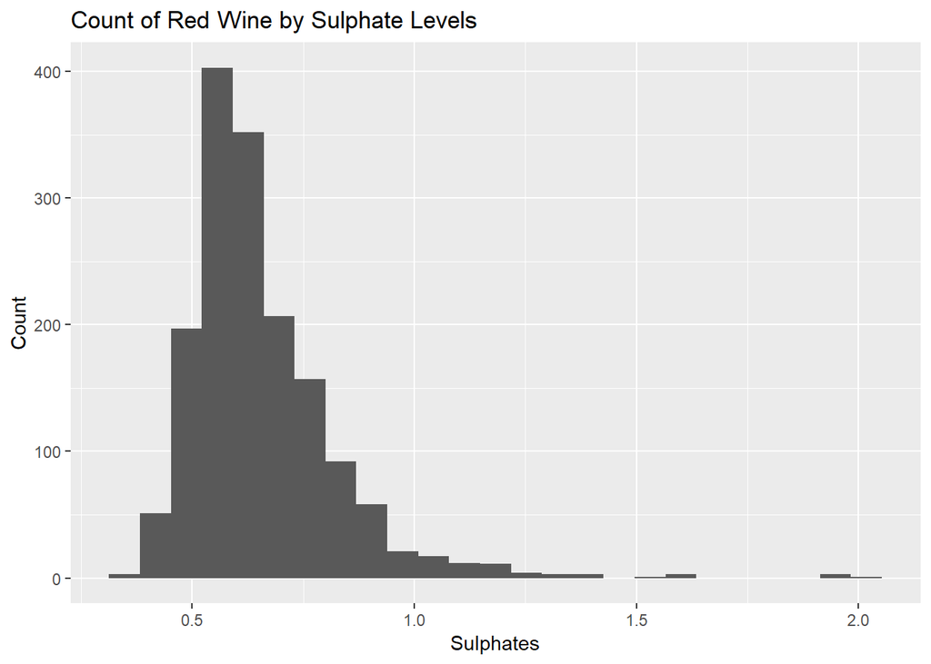

```
## [1] 0.62
```

```
## [1] 0.6581488
```

We can see that Sulphates are Right skewed with a median of 0.62 and mean of 0.658

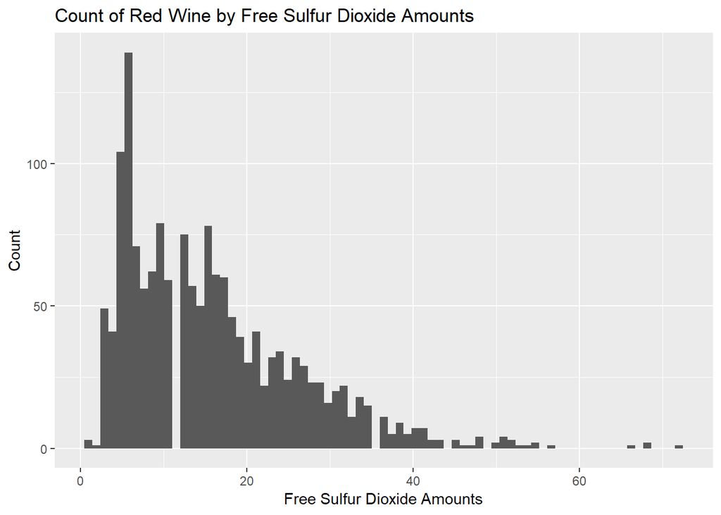

```
## [1] 14
```

```
## [1] 15.87492
```

With sulfur Dioxide counts we have a right skewed graph with median of 14 and mean of 15.87.

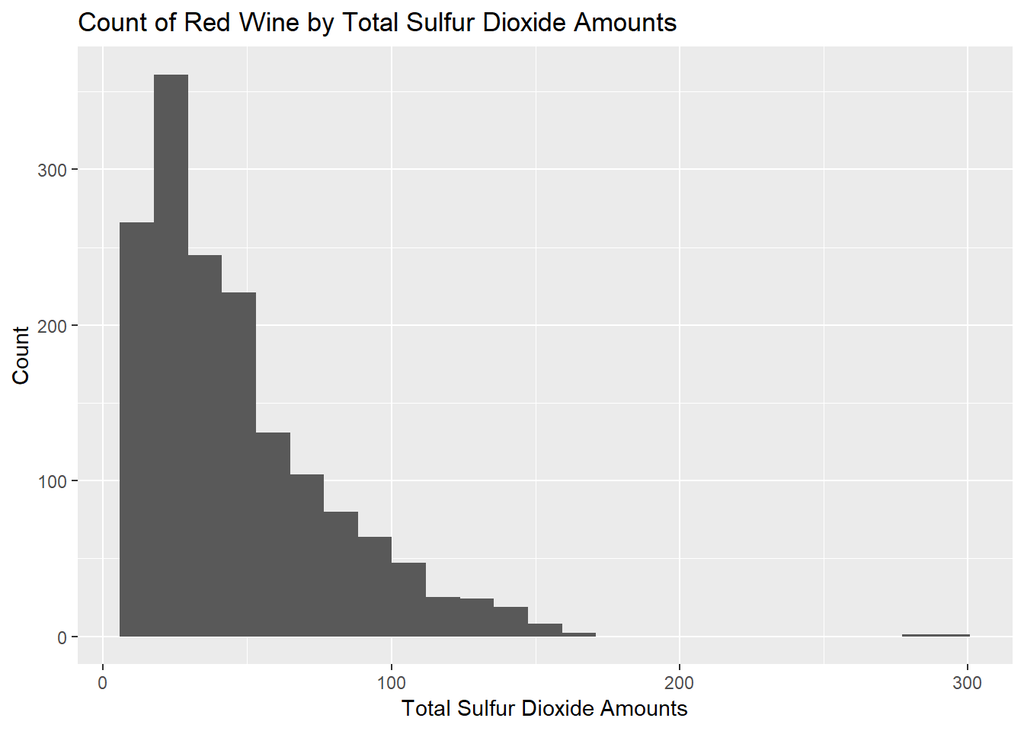

```
## [1] 38
```

```
## [1] 46.46779
```

We can see that Total Sulfur Dioxide amounts are right skewed with some far outliers. The median is 38 and mean is 46.47.

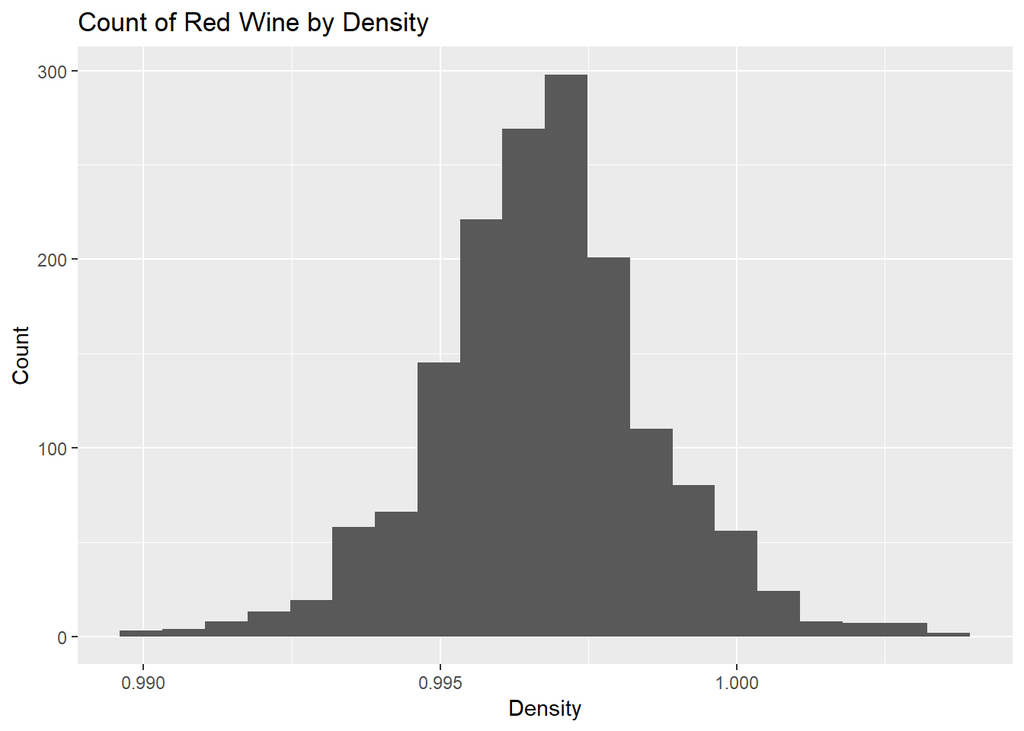

```
## [1] 0.99675
```

```
## [1] 0.9967467
```

We can see that Density has a normal distribution with a median of 0.99675 and mean of 0.9967467.

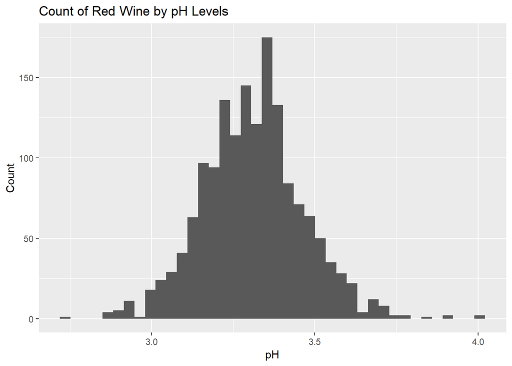

```
## [1] 3.31
```

```
## [1] 3.311113
```

We can see that pH levels have a normal distribution with a median of 3.31 and mean of 3.311113.

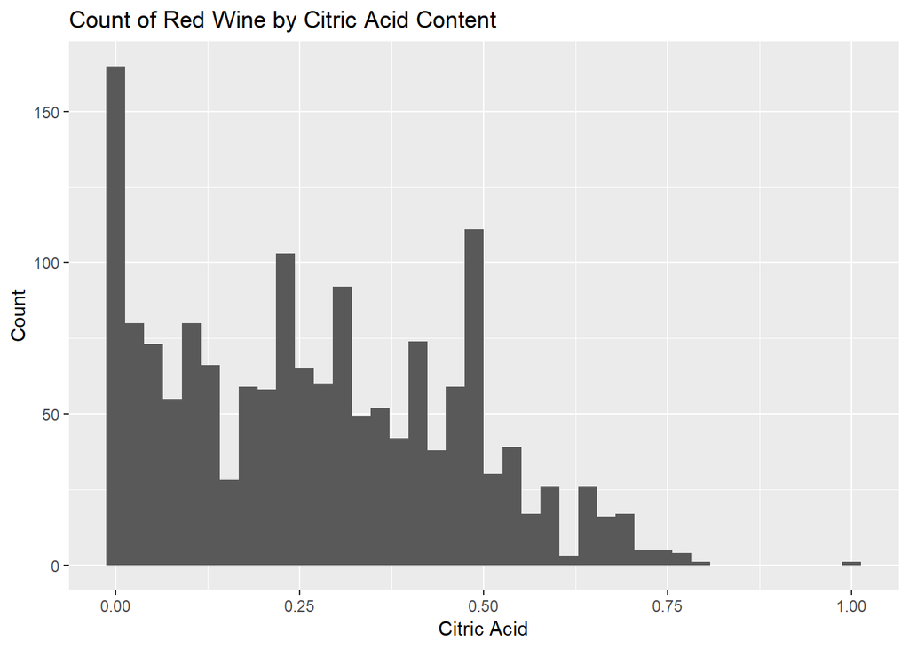

We can see that Citric Acid Content has a non-normal distribution.

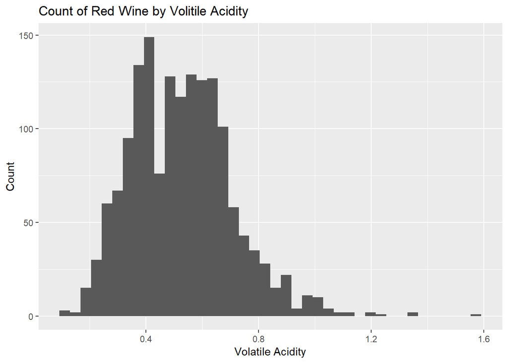

```
## [1] 0.52
```

```
## [1] 0.5278205
```

The distribution of Volatile Acidity seems to have a right skew to it that has a median of 0.52 and mean of 0.528.

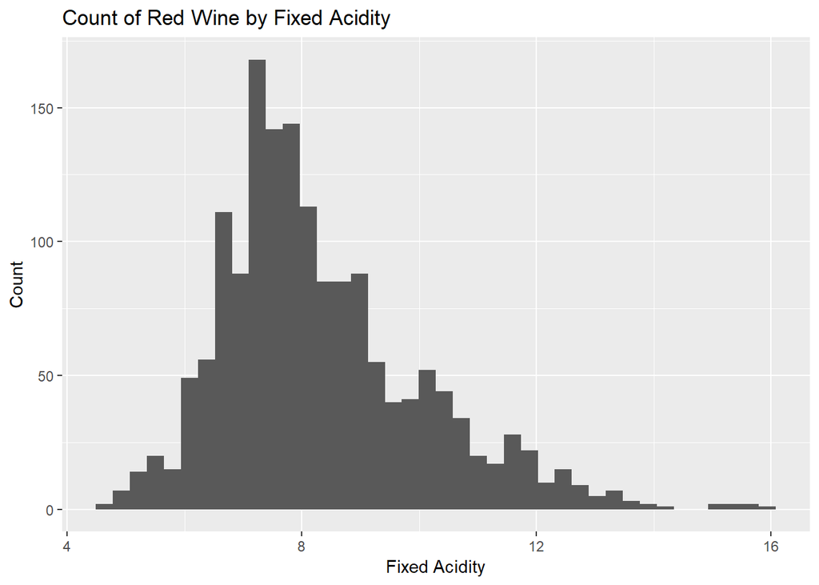

The distribution of Fixed Acidity has a right skew to it that has a median of 7.9 and mean of 8.319637.

# Univariate Analysis

### What is the structure of your dataset?

This dataset contains 12 variables on 1599 different red wines.

We can also see that:

Most of the variables are right skewed.

The bulk of the wines pH levels range from 3 to 3.6

There are some outliers that exist that may need to be ommitted in further analysis.

### What is/are the main feature(s) of interest in your dataset?

I am mainly focusing on the quality as compared pH levels. I want to see if there is a coorrelation between how the quality of wine is rated and the various acidity types.

### What other features in the dataset do you think will help support your

investigation into your feature(s) of interest?

The acidity levels will also play a factor in this data set due to that fact that they directly impact the pH levels.

### Did you create any new variables from existing variables in the dataset?

I created groupings of quality based on the normal distribution of the count of wines by quality. This led me to create three groups which consists of:

Above Average > 7 Average < 7 > 5 Below Average < 5

By doing this it will help me to categorize the sets and make it easier to see any differences that may lie between the win qualities.

### Of the features you investigated, were there any unusual distributions?

Did you perform any operations on the data to tidy, adjust, or change the form  
of the data? If so, why did you do this?

As I used an existing dataset that was already clean I did not perform any cleaning operations. One graph that did stand out was the Citric Acid which had a non-normal distribution.

# Bivariate Plots Section

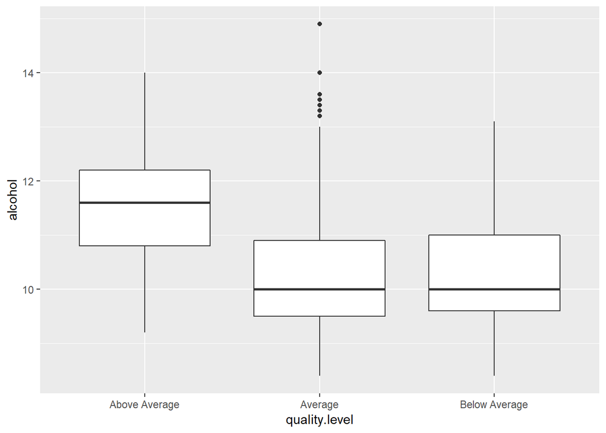

This plot shows that the higher rated wines tend to have a higher alcohol content. It is interesting to see that there is a slight dip in alcohol content when you move from the below average to average groups of wine.

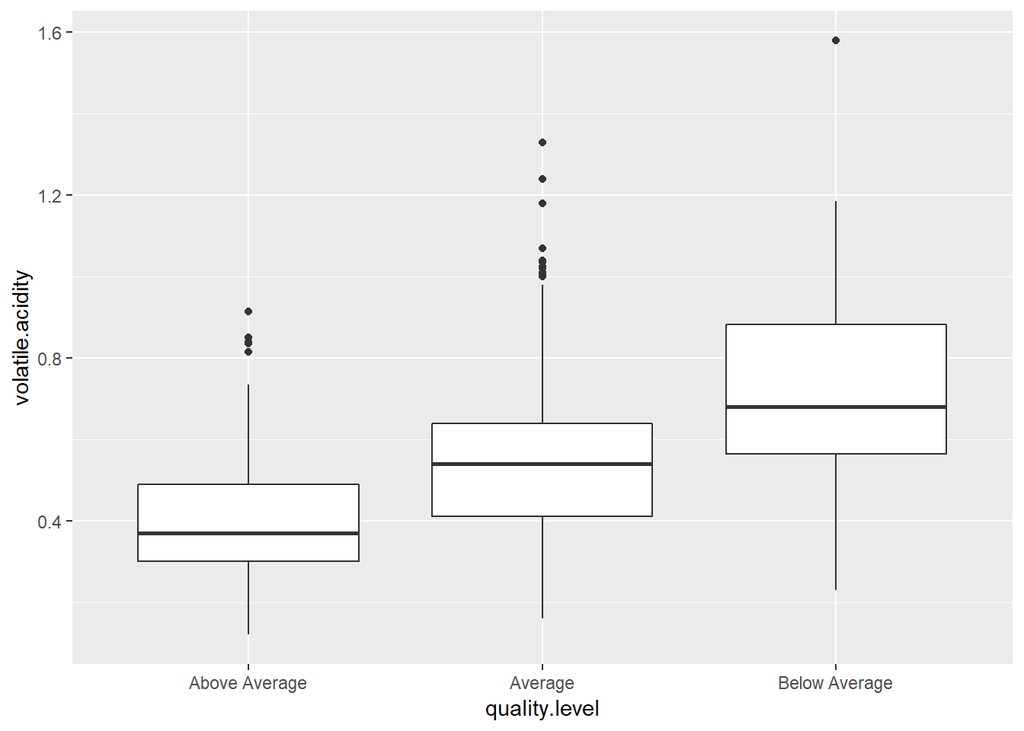

From this graph we see that there is an obvious relationship between the quality of a wine and the volitile acidity level. Lower the volatile acidity, higher the quality of wine.

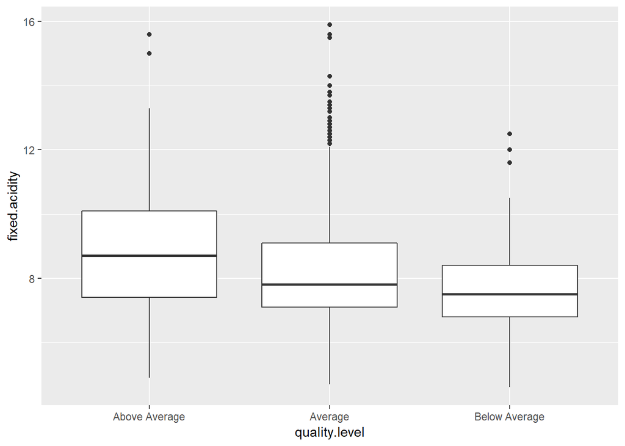

From this graph we see that there is an obvious relationship between the quality of a wine and the fixed acidity level. Higher the fixed acidity, higher the quality of wine.

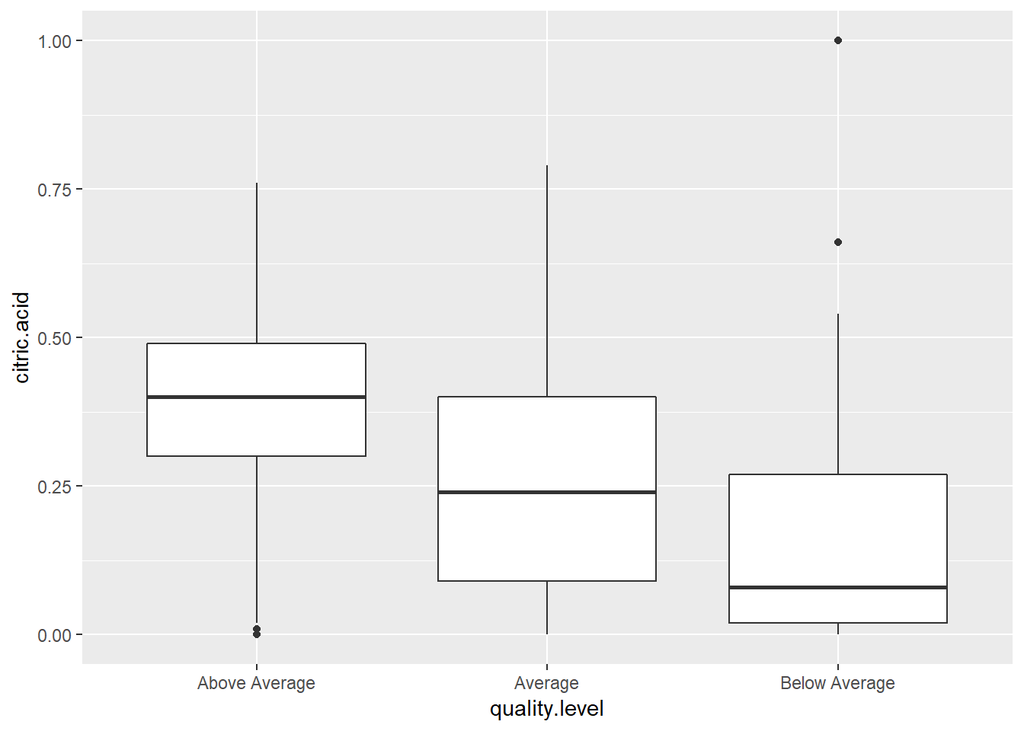

From this graph we see that there is an obvious relationship between the quality of a wine and the citric acid level. Higher the citric acid, higher the quality of wine.

[figure not shown]

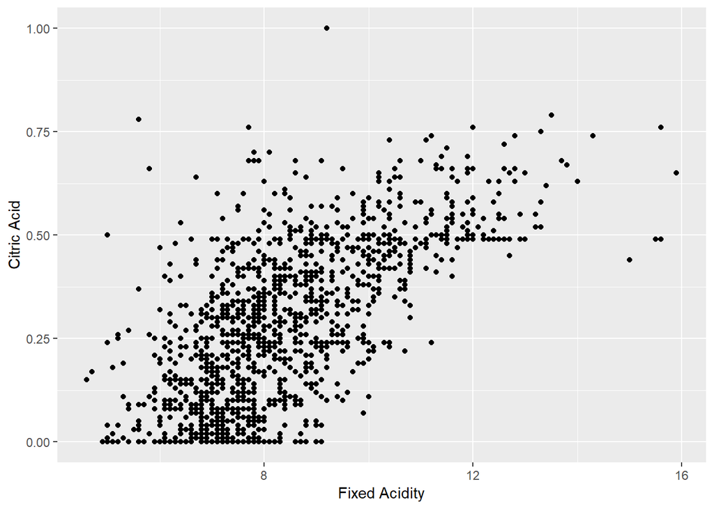

# Bivariate Analysis

### Talk about some of the relationships you observed in this part of the

investigation. How did the feature(s) of interest vary with other features in  
the dataset?

I observed:

I found it interesting that there was a slight dip in the alcohol content range for the average grouping when compared to the other tow groups. It is also interesting to see that the volitive and fixed acidity levels when compared to quality level are inverse of each other.

This shows us that people tend to enjoy windes that have a higher level of fixed acidity and citric acid while maintaining lower levels of volatile acidity.

### Did you observe any interesting relationships between the other features

(not the main feature(s) of interest)?

Some of the interesting things I observed were:

The relationship of alcohol to density is negative.

THe relationship of fixed acidity to citric acid is positive.

### What was the strongest relationship you found?

# Multivariate Plots Section

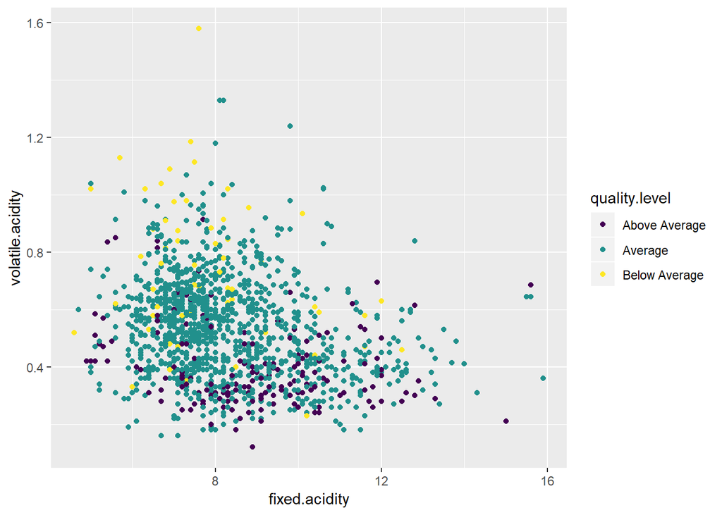

We can see here that lower quality wines tend to have higher volatile acidity while having a lower fixed acidity. There are a few outliers in the below average range that violate this.

We can also see that above average wines tend to have a volitile acidity no more than .8. Seeing this I can tell that volitile acidity has a much more significant affect on wine quality than fixed acidity does.

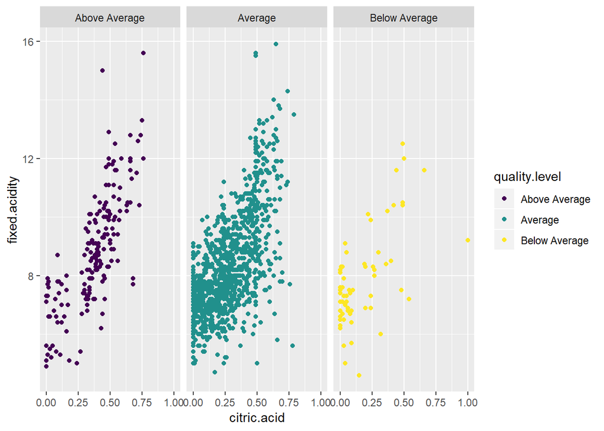

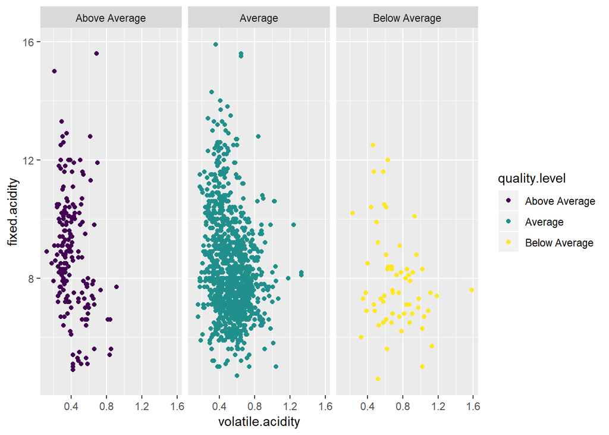

From here we can see that as the quality of the wine increases, the higher the fixed acidity and lower the volatile acidity become.+

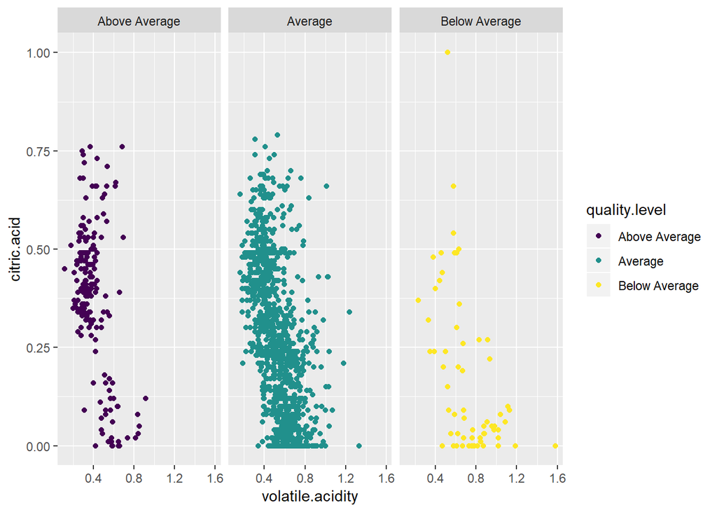

This graph shows that citric acid doesn’t always have a significant impact on the quality of the wine.

# Multivariate Analysis

### Talk about some of the relationships you observed in this part of the

investigation. Were there features that strengthened each other in terms of  
looking at your feature(s) of interest?

When comparing quality level, fixed acidity, and citric acid together and splitting it into their respective groups it became easier to see how the presence of high fixed acidity and citric acid are indicators of a wines quality.

The other thing that stood out to me was the relationship of volatile acidity, fixed acidity, and quality went together. The graph helped to make clear that fixed acidity has less of an impact on wine quality than volatile does.

### Were there any interesting or surprising interactions between features?

Overall, I found that comparing what I believe to be the key indicators to rate a quality wine that citric acid had less of a determining factor. Yes, you can see that as the overall quality of wine increases, the citric acid content gets higher but the final graph did a good job of showing the overlap with citric acid that exists between the three groups.

# Final Plots and Summary

### Plot One

[figure not shown]

### Description One

I chose this graph because I think it does the best job at showing how citric acid and fixed acidity are two of the more influential factors when it comes to the quality of a wine.

### Plot Two

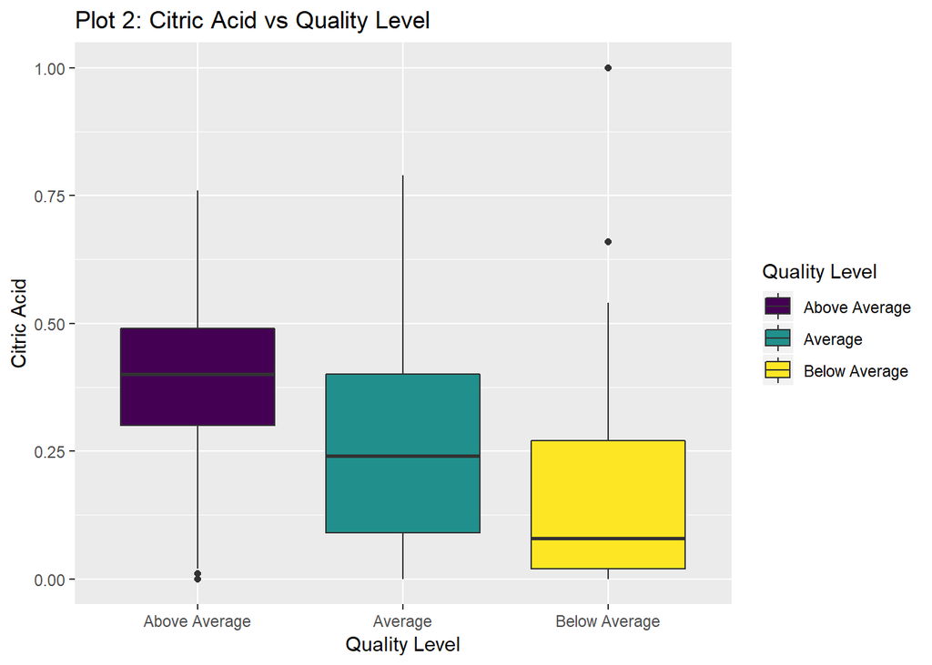

### Description Two

Here we can see that citric acid is proven to have a positive relationship with the quality of wine. It is interesting to see that the range of what is considered an above average wine in relation to citric acid content is much smaller than the average and below average groups. I also find it intregueing that there is a lot of overlap between the average and above average groups.

### Plot Three

[figure not shown]

### Description Three

Lastly, I selected this graph because it shows the other acid that has one of the greater impacts on the quality of wine. Using the second and third plot you can better understand what you are seeing in the first plot and gain a deeper understanding of what the information is showing. ——

# Reflection

WThe red wine dataset contained information on 1599 different red wines and 12 different attributes on each. As I preformed my exploration I tried to find different ways to visualize the relationship of the various acid types and how it affects the quality of the wine. I discovered that some styles of plots are much better at presenting less specific data where as others are best for comparing single variables. For instance, I had to break the jitter plot into the three seperate quality groups because if I kept them overlapped it makes it difficult to pull any meaning from the plot. The use of single variable plots and graphs allows you to gain more granular insight on specific attributes. By doing this I can better understand the behavior of the dataset and identify any anamolies that may make interpreting a more complex, multivariable graph difficult.

Moving forward, I believe growing this dataset to the point that it looks at the geographic location of the people who rate the wines would be a great benefit. With that, we could identify each country and the preferred attributes that they like in their wine. By doing this the wine makers would be able to start targeting different countries and allocate wines with certain characteristics to areas that best prefer them.

### Struggles / Successes

Throughout the project I spent a lot of time inputing different graph types for the same metrics over and over to see which did best to represent the information I was looking at. I struggle for a bit in trying to find a graph that was easy to read without getting too confusing with points on top of points. I ended up discovering how to apply facet_wrap to point and jitter plots which allowed me to reduce the clutter making the plots more readable and easy to use.